# task 10 - 2

Paulius Kostickis

Thursday, April 21, 2016

2.For this exercise, use the monthly Australian short-term overseas visitors data, May 1985–April 2005. (Data set: visitors.) (a) Make a time plot of your data and describe the main features of the series. (b) Forecast the next two years using Holt-Winters’ multiplicative method. (c) Why is multiplicative seasonality necessary here? (d) Experiment with making the trend exponential and/or damped. (e) Compare the RMSE of the one-step forecasts from the various methods. Which do you prefer? (f) Check that the residuals from the best model look like white noise.

#### a) duomenų grafikas

Matosi stiprėjantis sezoniškumas ir silpnėjantis trendas.

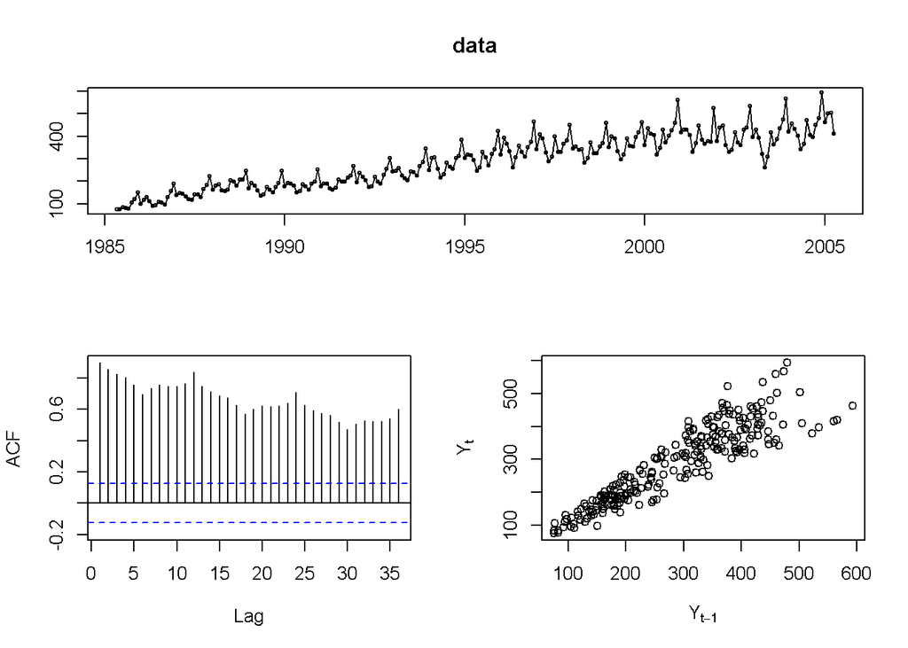

```r
tsdisplay(data, plot.type="scatter")
```

#### b) Holt-Winter multiplikatyvus metodas

Matome prognozė gerai prisitaikiusi prie duomenų trendo ir sezoniškumo:

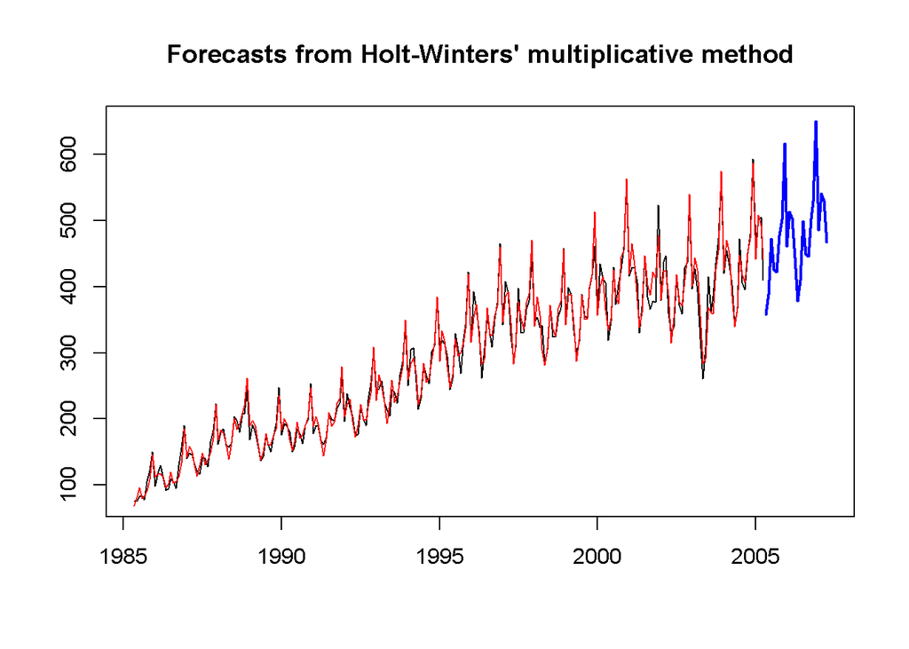

```r
fit1 <- hw(data, h=24, seasonal="mult")
plot(fit1, plot.conf=FALSE)
lines(fitted(fit1), col="RED")
```

#### c) Kodėl Holt-Winter multiplikatyvus metodas?

Kadangi kylant duomenim proporcingai didėja ir sezoniškumo svyravimai, tuomet reikia į tai atsižvelgti prognozėje. Tai būtent ir padaro šis metodas.

#### d) Eksponentinis ir slopinamasis metodai

Šiuo atveju eksponentinis ir slopinamasis modelis labai tinka šiems duomenims, nes būtent slopinamajame metode mažėja trendo poveikis visai kaip šiuose duomenyse:

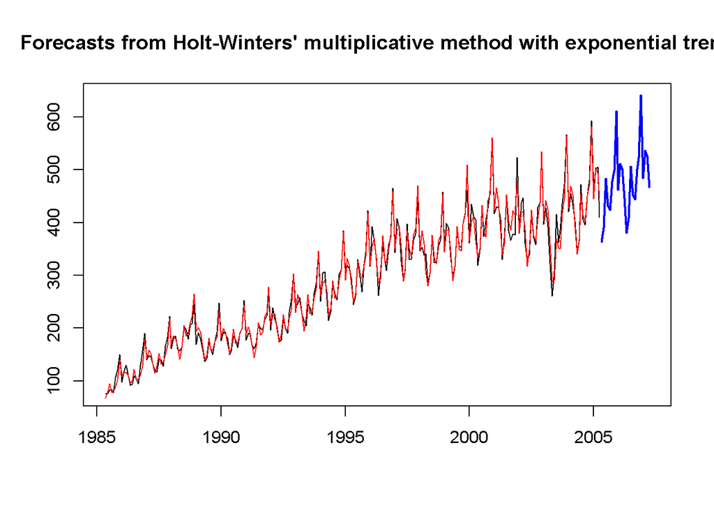

```r
fit2 <- hw(data, h=24, seasonal="mult", exponential=TRUE)
plot(fit2, plot.conf=FALSE)
lines(fitted(fit2), col="RED")
```

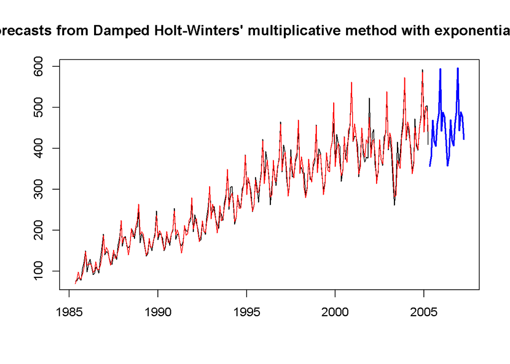

```r
fit3 <- hw(data, h=24, seasonal="mult", exponential=TRUE,damped=TRUE)
plot(fit3, plot.conf=FALSE)
lines(fitted(fit3), col="RED")
```

Visos prognozės:

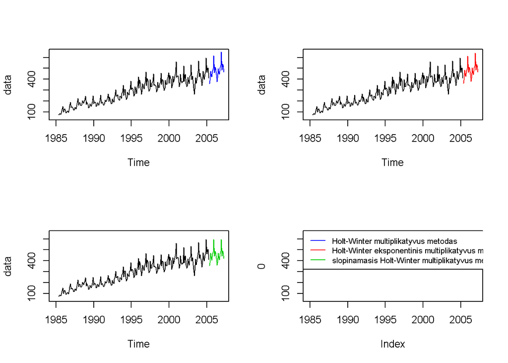

```r
par(mfrow=c(2,2))
plot(data, xlim=c(1985,2007), ylim=c(50,650))
lines(fit1$mean, col=4, lwd=1)
plot(data, xlim=c(1985,2007), ylim=c(50,650))
lines(fit2$mean, col=2)
plot(data, xlim=c(1985,2007), ylim=c(50,650))
lines(fit3$mean, col=3)
plot(0, xlim=c(1985,2007), ylim=c(50,650))
legend("topleft", lty=1, cex=0.8, lwd="1", col=c(4,2,3), legend=c("Holt-Winter multiplikatyvus metodas","Holt-Winter eksponentinis multiplikatyvus metodas","slopinamasis Holt-Winter multiplikatyvus metodas"))
```

#### e) RMSE modelių rodikliai

```r
kable(data.frame(Multiplikatyvus=accuracy(fit1)[2],eksponentinis_multiplikatyvus=accuracy(fit2)[2],Damped_multiplikatyvus=accuracy(fit3)[2]))
```

| Multiplikatyvus | eksponentinis_multiplikatyvus | Damped_multiplikatyvus |
| --- | --- | --- |
| 14.52211 | 14.6899 | 14.46091 |

Geriausiai pasirodė fit3 - slopinamasis Holt-Winter multiplikatyvusis metodas, kuris atsižvelgia į trendo mažėjimą ir sezoniškumo didėjimą.

#### f) Ar liekanos baltasis triukšmas?

```r
mean(fit3$res)
```

```
## [1] 0.002076252
```

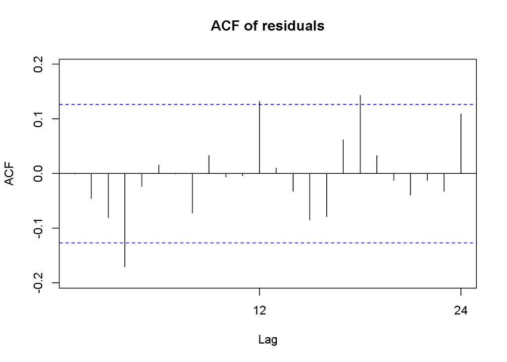

```r
Acf(fit3$res, main="ACF of residuals")
```

```r
Box.test(fit3$res)
```

```
##
##  Box-Pierce test
##
## data:  fit3$res
## X-squared = 1e-04, df = 1, p-value = 0.9908
```

```r
shapiro.test(fit3$res)
```

```
##
##  Shapiro-Wilk normality test
##
## data:  fit3$res
## W = 0.9861, p-value = 0.01987
```

Histograma liekanų:

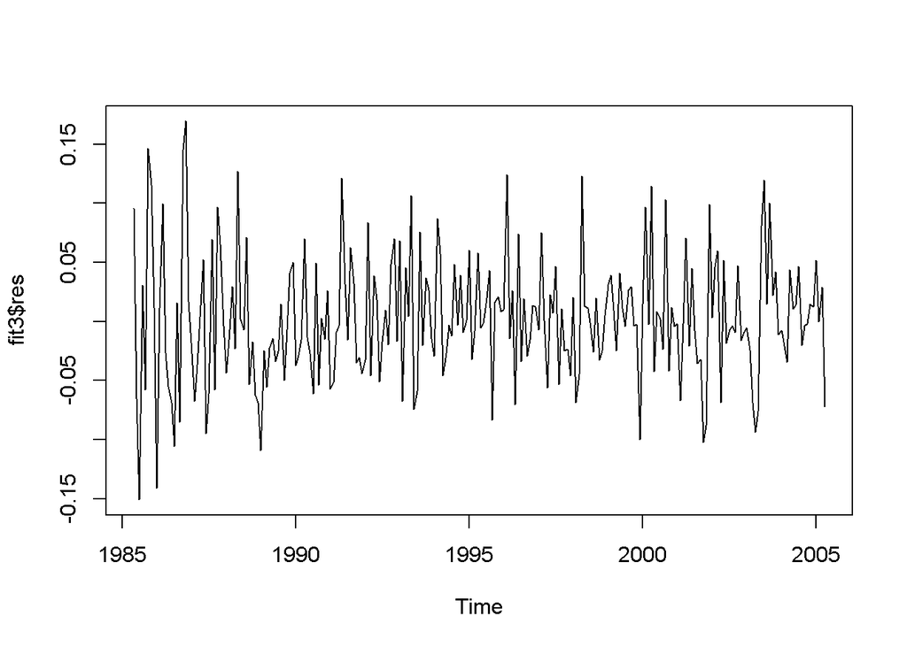

```r
plot(fit3$res)
```

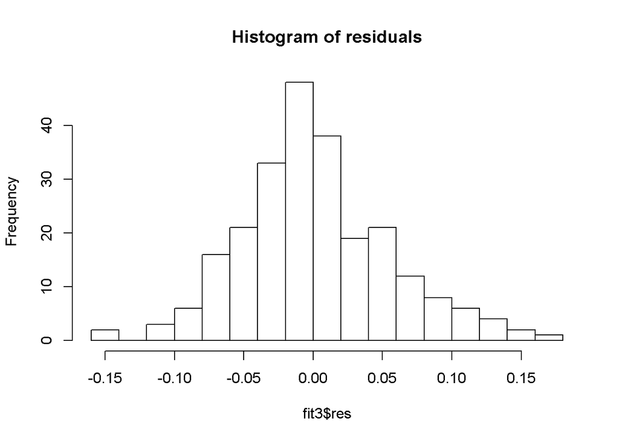

```r
hist(fit3$res, nclass="FD", main="Histogram of residuals")
```

Tačiau palyginę grafikus(baltojo triukšmo grafikas ir liekanų grafikas):

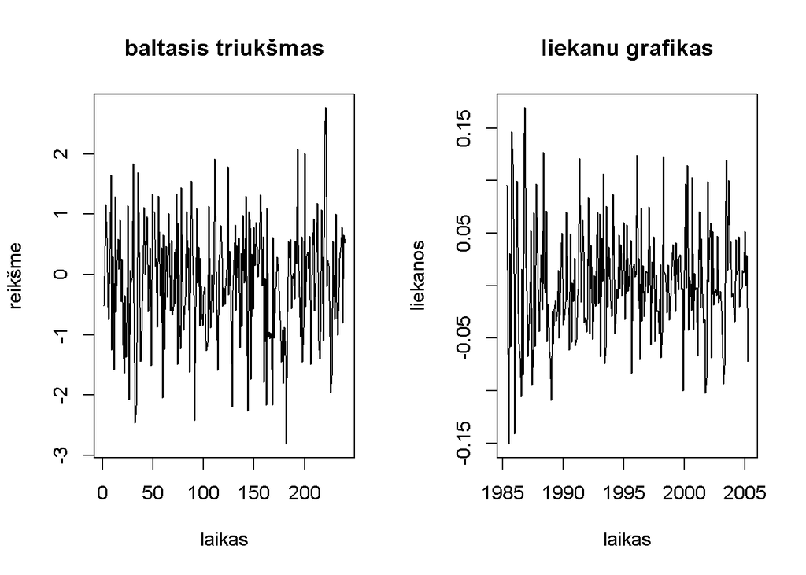

```r
par(mfrow=c(1,2))
plot(x=1:length(fit3$res),y=rnorm(length(fit3$res),0,1),type="l", main="baltasis triukšmas",ylab="reikšmė", xlab="laikas")
plot(fit3$res, main="liekanų grafikas",ylab="liekanos", xlab="laikas")
```